# Ensemble Learning

The goal of ensemble methods is to combine different classifiers into a metaclassifier that has better generalization performance than each individual classifier alone<sup>4</sup>.

Most popular ensemble methods use the majority voting principle.

## Majority Voting

Aggregation can be done by simply selecting the class label that has been predicted by the majority of the classifiers (more than 50% of votes) for 'hard voting'.

Majority vote refers to binary class decisions but can be generalized to a multi-class setting using 'plurality voting'<sup>4</sup>.

To predict a class label via simple majority or plurality voting, we can combine the predicted class labels of each individual classifier, $C_m$, and select the class label, $\hat y$, that received the most votes<sup>4</sup>.

We can write the weighted majority vote as follows<sup>4</sup>:

$\hat y = \text{arg} {\text{max} \atop i} \sum^m_{j=1}W_jI_A(C_j(x)=i)$

where $w_j$ is a weight associated with a base classifier, $C_j$ ; $\hat y$ is the predicted class label of the ensemble; $A$ is the set of unique class labels; $I_A$ is the characteristic function or indicator function, which returns 1 if the predicted class of the $j$th classifier matches i(C_j(x)=i. For equal weights, we can simplify this equation and write it as follows:

$\hat y = mode\{C_1(x), C_2(x),...,C_m(x)\}$

In binary classification (-1,1) we can therefore write the majority vote prediction as<sup>4</sup>:

$C(x) = \text{sign}\left[ \sum^m_jC_j(x)\right] = \left\{{1 \: \text{if}\: \sum_j C_j(x) \geq 0 \atop -1 \quad\text{otherwise}} \right\}$

**TODO**

- penguins data may no longer be the best example to demonstrate these methods...

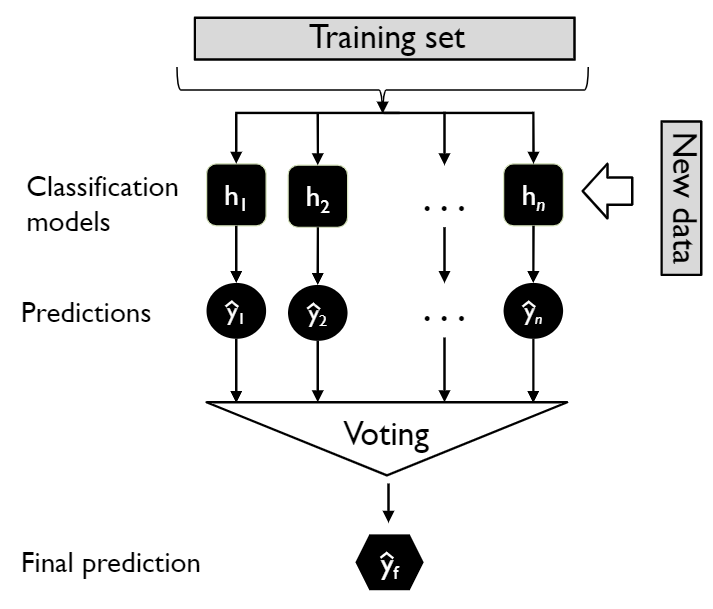

Particular classifiers return the probability of a predicted class label and this can be used for 'soft voting' instead of class labels<sup>4</sup>. The modified version of the majority vote for predicting class labels from probabilities can be written as:

$\hat y = \text{arg} {\text{max} \atop i} \sum^m_{j=1}w_jp_{ij}$,

where $p_{ij}$ is the predicted probability of the $j$th classifier for class label $i$.

Soft voting often achives a higher performance than hard voting because highly confident votes are given more weight<sup>3</sup>.

## Averaging Methods

Averaging methods build several *separate* estimators and then, as their name suggets, average their predictions.

Averaging methods generally work best when the predictors are as independent as possible, so one way of achiving this is to get diverse classifiers. This increases the chance they each make different types of errors which in combination will improve the overall accuracy<sup>3</sup>.

1. Raschka, Sebastian, and Vahid Mirjalili. Python Machine Learning, 2nd Ed. Packt Publishing, 2017.
2. Géron, A. (2017). Hands-on machine learning with Scikit-Learn and TensorFlow: concepts, tools, and techniques to build intelligent systems. " O'Reilly Media, Inc.".

### Bagging

A bagging classifier is an ensemble of base classifiers, each fit on random subsets of a dataset. Their predictions are then pooled or aggregated to form a final prediction. This reduces *variance* of an estimator so can be a simple way to reduce overfitting and increase prediction accuracy<sup>1</sup>.

This is because the variance of the mean $\bar Z$ of $n$ independent observations, $Z_1,...,Z_n$, is given by $\sigma^2/n$; meaning averaging a set of observations reduces variance. Can can use this by taking many separate training sets, $B$, from the population, building a separate prediction model using each training set, $\hat f^1(x),\hat f^2(x),...,\hat f^B(x)$, and average the resulting predictions<sup>2</sup>:

$\hat f_{avg}(x)=\frac{1}{B}\sum_{b=1}^B\hat f^b(x)$.

However we generally do not have access to multiple training sets so instead we can bootstrap by taking repeated samples from a (single) training data set to create multiple bootstrapped training data sets, $B$. We then train our method on the $b$th bootstrapped training set to get $f^{∗b}(x)$ , and finally average all the predictions, to obtain<sup>2</sup>:

$\hat f_{bag}(x) = \frac{1}{B}\sum_{b=1}^B\hat f^{∗b}(x)$.

1. https://scikit-learn.org/stable/modules/ensemble.html
2. James, Gareth, Daniela Witten, Trevor Hastie, and Robert Tibshirani. An introduction to statistical learning. Vol. 112. New York: springer, 2013.

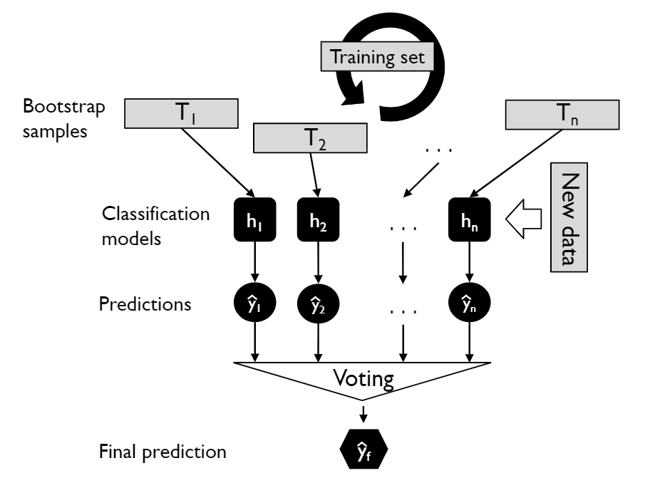

Specifically, bagging is when sampling is produced with replacement<sup>2</sup>, and without replacement being called *pasting*<sup>3</sup>.

Pasting is designed to use smaller sample sizes than the training dataset in cases where the training dataset does not fit into memory<sup>3</sup>.

Both bagging and pasting allow training to be sampled several times across multipule predictors, with bagging only allowing several samples for the same predictor <sup>4</sup>.

1. Breiman, L. (1996). Bagging predictors. Machine learning, 24(2), 123-140.
2. Breiman, L. (1999). Pasting small votes for classification in large databases and on-line. Machine learning, 36(1-2), 85-103.
3. Géron, A. (2017). Hands-on machine learning with Scikit-Learn and TensorFlow: concepts, tools, and techniques to build intelligent systems. " O'Reilly Media, Inc.".

```
Original Data
```

```
array([0, 1, 2, 3, 4, 5, 6, 7, 8, 9], dtype=int64)
```

```
Bagging (0.8 Samples)
```

```
[array([9, 2, 9, 7, 7, 8, 3, 2]),
 array([7, 3, 7, 3, 9, 5, 3, 9]),
 array([6, 0, 7, 7, 9, 8, 5, 8]),
 array([0, 5, 7, 4, 1, 3, 6, 2]),
 array([6, 9, 6, 3, 3, 8, 3, 7])]
```

```
Pasting (0.8 Samples)
```

```
[array([6, 7, 5, 8, 3, 0, 4, 1]),
 array([0, 4, 5, 6, 2, 1, 8, 9]),
 array([5, 3, 9, 4, 8, 2, 1, 7]),
 array([9, 3, 6, 1, 8, 4, 2, 7]),
 array([1, 5, 4, 2, 0, 8, 7, 3])]
```

In practice, *bagging* tends to work best with complex models<sup>1</sup>, so although bagging is useful when applied to regression methods, they are particularly useful for decision trees<sup>2</sup>.

Bagging has been demonstrated to give impressive improvements in accuracy by combining together hundreds or even thousands of trees into a single procedure.

These trees are grown deep, and are not pruned so each individual tree has high variance, but low bias. Averaging these $B$ trees reduces the variance.

To apply bagging to **regression trees**, we simply:

1. construct $B$ regression trees using $B$ bootstrapped training sets,
2. average the resulting predictions.

To apply bagging to **decision trees**, we simply:

1. construct $B$ decision trees using $B$ bootstrapped training sets,
2. take a majority vote of the resulting predictions.
1. https://scikit-learn.org/stable/modules/ensemble.html
2. James, Gareth, Daniela Witten, Trevor Hastie, and Robert Tibshirani. An introduction to statistical learning. Vol. 112. New York: springer, 2013.
3. Géron, A. (2017). Hands-on machine learning with Scikit-Learn and TensorFlow: concepts, tools, and techniques to build intelligent systems. " O'Reilly Media, Inc.".

#### Out-of-Bag Error Estimation

Using a bagged model means we can get a validation/test error without using cross-validation.

On average, each bagged tree uses around two-thirds of the observations<sup>1, REF</sup>, therefore we can predict these out-of-bag (OOB) observations using only the trees that were not fit using those observations.

With a sufficiently amount of bags, OOB error is virtually equivalent to leave-one-out cross-validation error, which is convenient when performing bagging on large data sets for which cross-validation would be computationally onerous<sup>1</sup>.

1. James, Gareth, Daniela Witten, Trevor Hastie, and Robert Tibshirani. An introduction to statistical learning. Vol. 112. New York: springer, 2013.

#### Variable Importance Measures

Bagging improves prediction accuracy at the expense of interpretability.

However we can use the feature importance method as previously discussed, to get an overall summary of the importance of each predictor across trees.

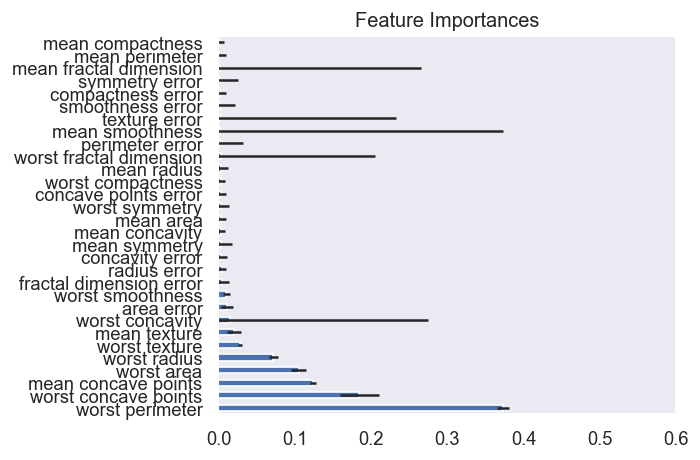

### Random Forests

*"Random forests are among the most widely used machine learning algorithm, probably due to their relatively good performance “out of the box” and ease of use (not much tuning required to get good results)."*<sup>web1</sup>

Random forests are essentally bagged tree classifiers, but decorrelate the trees by using a random sample of features each time a split in a tree is considered.

The random forest algorithm can therefore be summarized in four steps<sup>1</sup>:

**Algorithm. Random Forests**

> 1. Draw a random bootstrap sample of size $n$.
> 2. Grow a decision tree from the bootstrap sample. At each node:

>    a. Randomly select $d$ features without replacement (typically the square root of the total number of predictors).

>    b. Split the node using the feature that provides the best split according to the objective function.
> 3. Repeat the steps above $k$ times.
> 4. Aggregate the prediction by each tree to assign the class label by majority vote.
1. Raschka2017

web1. https://github.com/rasbt/stat451-machine-learning-fs20/blob/master/L07/07-ensembles__notes.pdf

By not allowing the model to use the majority of the available predictors, we ensure the bagged trees look different from each other. If there is a particularly strong set of predictors in the data, then without randomly selecting features, the bagged trees will look quite similar to each other and predictions will be highly correlated. Averaging highly correlated quantities does not lead to as large of a reduction in variance as averaging many uncorrelated quantities<sup>2</sup>.

1. Raschka2017
2. James, Gareth, Daniela Witten, Trevor Hastie, and Robert Tibshirani. An introduction to statistical learning. Vol. 112. New York: springer, 2013.

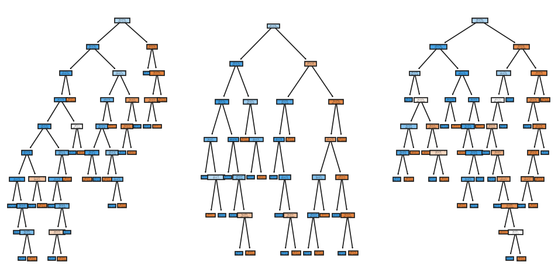

Lets look at how a descion boundary created by a bagged tree could generalise better than a single tree

**TODO**

- do this on training and val data to show how the val data could cross the boundary?
- Also cross validate to get the settings rather than have the default as it looks weird.

```
Randomsearch took 53.91 seconds for 15 candidates
```

|  | param_n_estimators | param_max_samples | mean_test_score | std_test_score |
| --- | --- | --- | --- | --- |
| 12 | 866 | 0.190387 | 0.905123 | 0.033407 |
| 4 | 751 | 0.23626 | 0.903369 | 0.033675 |
| 8 | 492 | 0.254452 | 0.903354 | 0.032782 |
| 3 | 131 | 0.286089 | 0.899798 | 0.033650 |
| 2 | 849 | 0.352333 | 0.898075 | 0.035759 |

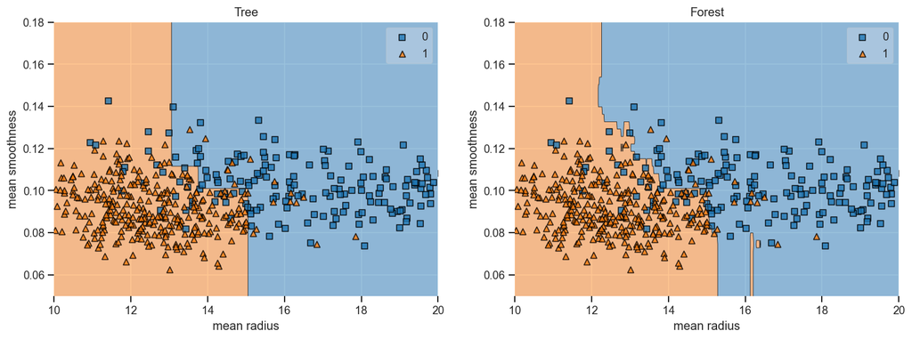

#### Extremely Randomized Trees

As averaging methods work best when the predictors are as independent as possible<sup>2</sup>, we may specifically want our trees in our ensemble to be more independent.

An extratree is similar to a tree classifier except it more randomized and thusly produces more complex trees.

Instead of looking for the most discriminative thresholds, thresholds are drawn at random for each candidate feature and the best of these randomly-generated thresholds is picked as the splitting rule.

When used in an ensemble, this usually allows to reduce the variance of the model a bit more, at the expense of a slightly greater increase in bias<sup>2</sup>.

1. Geurts, P., Ernst, D., & Wehenkel, L. (2006). Extremely randomized trees. Machine learning, 63(1), 3-42.
2. https://scikit-learn.org/stable/modules/ensemble.html
3. Géron, A. (2017). Hands-on machine learning with Scikit-Learn and TensorFlow: concepts, tools, and techniques to build intelligent systems. " O'Reilly Media, Inc.".

As we can see how just one tree looks, this is a very complex model!

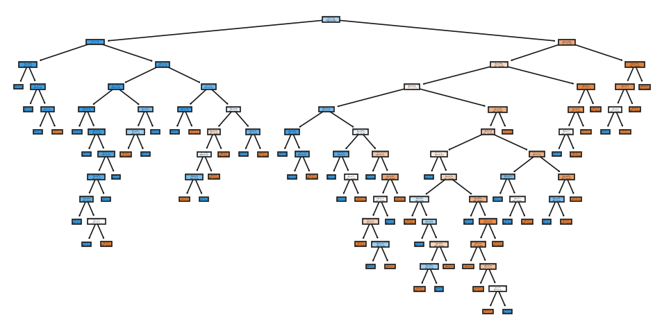

# Associated Exercises

# References

1. James, Gareth, Daniela Witten, Trevor Hastie, and Robert Tibshirani. An introduction to statistical learning. Vol. 112. New York: springer, 2013.
2. Gorman KB, Williams TD, Fraser WR (2014). Ecological sexual dimorphism and environmental variability within a community of Antarctic penguins (genus Pygoscelis). PLoS ONE 9(3):e90081. https://doi.org/10.1371/journal.pone.0090081
3. Géron, A. (2017). Hands-on machine learning with Scikit-Learn and TensorFlow: concepts, tools, and techniques to build intelligent systems. " O'Reilly Media, Inc.".
4. Raschka, Sebastian, and Vahid Mirjalili. Python Machine Learning, 2nd Ed. Packt Publishing, 2017.